# PRÁCTICA 3A: CLASIFICACIÓN ZERO-SHOT

PROFESOR: DR. LUIS GUILLERMO RUIZ VELÁZQUEZ

ESTUDIANTE: EDGAR SANTIAGO GONZALEZ MARTINEZ

## Introducción

En esta actividad implementamos una clasificación **zero-shot** con CLIP usando `open_clip_torch`. Cargamos el modelo `ViT-B-32` con el checkpoint `laion2b_s34b_b79k`, definimos cuatro prompts (“a desert”, “a mountain”, “a sea”, “a sunset”) y generamos embeddings de texto e imagen con el *preprocess* oficial. Tras normalizarlos, calculamos similitud coseno mediante un producto matricial y, para cada imagen, tomamos la predicción **top-1**. La evaluación se realiza contra un *ground truth* **multietiqueta**: consideramos **acierto** cuando la clase top-1 pertenece al conjunto de etiquetas verdaderas del ejemplo. Finalmente consolidamos los resultados en un DataFrame y visualizamos las **clasificaciones** en una rejilla de miniaturas, lo que permite inspeccionar patrones de error y co-ocurrencias entre categorías.

El material proporcionado para el ejercicio y el video fueron de vital ayuda para poder realizar lo siguiente.

# CLIP

En este notebook vamos a ver un ejemplo de como se puede usar CLIP para codificar imágenes y texto.

## Conexión de Google Drive con Google Colab

Como primer procedimiento, se conecta Google Drive con Google Colab para poder acceder a los archivos almacenados en la nube.

La instrucción `from google.colab import drive` permite importar el módulo `drive`, el cual posibilita que Colab interactúe con Google Drive. El comando `drive.mount('/content/drive')` monta Google Drive en la carpeta `/content/drive`. Al ejecutarlo, Colab solicitará un permiso de acceso. Una vez concedido, los archivos estarán disponibles para lectura y escritura dentro del notebook.

```python
# Cargar Google Drive
from google.colab import drive
drive.mount('/content/drive')
```

## Instalación de `open_clip_torch`

En este paso se instala desde PyPI la librería OpenCLIP para PyTorch (modelos y utilidades CLIP).

```python
pip install open_clip_torch
```

## Importación de librerías

Ahora bien, en estas líneas cargan los módulos base del proyecto: `torch` para manejar tensores y cómputo acelerado (CPU/GPU), `PIL.Image` para abrir y procesar imágenes, `open_clip` para usar modelos CLIP (carga, tokenización e inferencia) y `glob` para listar archivos con patrones como `*.jpg` en carpetas.

```python
import torch
from PIL import Image
import open_clip
import glob
```

## Cargar el modelo CLIP de openCLIP

Se crea el modelo **ViT-B-32** preentrenado en **`laion2b_s34b_b79k`**, junto con su **pipeline de preprocesamiento** de imágenes (la segunda salida se descarta con `_`). Luego se pone el modelo en **modo evaluación** (`eval()`) para desactivar comportamientos de entrenamiento (BatchNorm/Dropout). Finalmente, se obtiene el **tokenizer** correspondiente para convertir textos a tokens compatibles con el modelo.

```python
model,_,preprocess= open_clip.create_model_and_transforms('ViT-B-32', pretrained='laion2b_s34b_b79k')
model.eval()  # model in train mode by default, impacts some models with BatchNorm or stochastic depth active
tokenizer = open_clip.get_tokenizer('ViT-B-32')
```

## Leer imágenes para probar

Después se obtiene con `glob.glob` una **lista** de rutas que coinciden con el patrón `*.jpg` dentro de `/content/drive/MyDrive/MCDI/3A/datos/images/`.

```python
images_files = glob.glob("/content/drive/MyDrive/MCDI/3A/datos/images/*.jpg")
len(images_files)
```

```
200
```

## Leer el archivo con las etiquetas de las imágenes

El archivo `miml_labels_1.csv` contiene una lista con los nombres de las imágenes y la categoría a la que pertenecen. Las posibles categorías son: Desierto, Montaña, Mar y Ocaso. Las primeras líneas del archivo son:

| Filenames | desert | mountains | sea | sunset | trees |
| --- | --- | --- | --- | --- | --- |
| 1.jpg | 1 | 0 | 0 | 0 | 0 |
| 2.jpg | 1 | 0 | 0 | 0 | 0 |
| 3.jpg | 1 | 0 | 0 | 0 | 0 |
| 4.jpg | 1 | 1 | 0 | 0 | 0 |
| 5.jpg | 1 | 0 | 0 | 0 | 0 |

(La etiqueta trees no la vamos a usar)

Para leer el archivo usamos el siguiente código que deja los datos en el diccionario `data`.

### Cargar etiquetas desde CSV

En esta parte, se abre el archivo CSV, lee todas las líneas, **omite el encabezado** (`lines[1:]`) y, por cada fila, **divide por comas** para obtener `file_name` y cuatro etiquetas (`desert`, `mountains`, `sea`, `sunset`), **ignorando la última columna** (`_`). Con eso construye `data`, un diccionario que **mapea cada imagen** a su **vector de etiquetas**.

```python
data = {}
with open("/content/drive/MyDrive/MCDI/3A/miml_labels_1.csv") as f:
  lines = f.readlines()
for l in lines[1:]:
  file_name, desert, mountains, sea, sunset, _ = l.split(",")
  data[file_name] = [desert, mountains, sea, sunset]
```

## Crear los embedding para las etiquetas.

Se crean `categorias` como una lista de *prompts* (empezar con “a …” ayuda en CLIP) y las pasa al `tokenizer` de `open_clip`, que devuelve un **batch** tensorizado (ids/máscara) listo para `model.encode_text`.

```python
categorias = ["a desert", "a mountain", "a sea", "a sunset"]
text = tokenizer(categorias)
```

Esto indica las dimensiones del batch tokenizado: **4** prompts (los de `categorias`) por **77** tokens cada uno. El **77** es la longitud de contexto fija de CLIP; textos más largos se **truncan** y más cortos se **rellenan** hasta 77.

```python
text.shape
```

```
torch.Size([4, 77])
```

En esta parte se reconstruye texto a partir de los **IDs de tokens** del primer prompt: `text[0]` se convierte a `numpy()` y `tokenizer.decode(...)` devuelve la cadena correspondiente.

```python
tokenizer.decode(text[0].numpy())
```

```
'<start_of_text>a desert <end_of_text>!!!!!!!!!!!!!!!!!!!!!!!!!!!!!!!!!!!!!!!!!!!!!!!!!!!!!!!!!!!!!!!!!!!!!!!!!'
```

Se ejecuta la inferencia **sin gradientes** (`no_grad`) y con **mixed precision** ; obtiene los *embeddings* con `model.encode_text(text)` y los **normaliza (L2)** (`/= ...norm(...)`) para dejarlos en norma 1, ideal para similitud coseno en CLIP.

```python
with torch.no_grad(), torch.cuda.amp.autocast():
    text_features = model.encode_text(text)
    text_features /= text_features.norm(dim=-1, keepdim=True)
```

Se muestra `torch.Size([4, D])`: **4** corresponde al número de *prompts* tokenizados y **D** es la dimensión del embedding del modelo (en `ViT-B-32` suele ser **512**).

```python
text_features.shape
```

```
torch.Size([4, 512])
```

## Crear los embeddings para las imágenes.

Carga la **quinta** ruta de `images_files` (índice `4`) y devuelve un objeto `PIL.Image`.

```python
img = Image.open(images_files[4])
```

Crea **una nueva imagen** de 100×100 píxeles a partir de `img`.

```python
img.resize((100, 100))
```

### Preprocesar la imagen y añadir dimensión de batch

`preprocess(img)` aplica la **pipeline de CLIP**: redimensiona, recorta al centro, convierte a **tensor CHW** y **normaliza** con las medias/desviaciones de CLIP. Con `.unsqueeze(0)` agrega la dimensión de **batch**.

```python
image = preprocess(img).unsqueeze(0)
image.shape
```

```
torch.Size([1, 3, 224, 224])
```

### Codificar y normalizar la imagen

Ejecuta inferencia **sin gradientes** y con **mixed precision**, obtiene el *embedding* de la imagen con `encode_image` y lo **normaliza (L2)** a norma 1, dejándolo listo para compararlo por **coseno** con los textos.

```python
with torch.no_grad(), torch.cuda.amp.autocast():
    image_features = model.encode_image(image)
    image_features /= image_features.norm(dim=-1, keepdim=True)
```

### Formas de los *embeddings*

Devuelve una **tupla** con las dimensiones: `image_features` suele ser `[1, D]` y `text_features` `[4, D]` (cuatro prompts); **D** es la dimensión del embedding. Al estar normalizados, el producto punto equivale a la **similitud coseno**.

```python
image_features.shape, text_features.shape
```

```
(torch.Size([1, 512]), torch.Size([4, 512]))
```

### Similitud texto–imagen y forma del resultado

`@` realiza **multiplicación matricial**: `text_features` `[4, D]` por `image_features.T` `[D, 1]` produce `sim` `[4, 1]`. Como ambos embeddings están **normalizados**, cada entrada de `sim` es la **similitud coseno** entre un prompt y la imagen (∈ [-1, 1]). `sim.shape` devuelve `torch.Size([4, 1])`.

```python
sim = text_features @ image_features.T
sim.shape
```

```
torch.Size([4, 1])
```

### Interpretación de `sim, categorias`

El resultado muestra un **par**: `sim` (tensor `[4,1]`) con la **similitud coseno** entre la imagen y cada prompt en `categorias`. Cuanto **más alto** el valor, mayor afinidad con la imagen. En la salida, el mayor score es **0.2460**, por lo que el *top-1* es **"a sea"**.

```python
sim, categorias
```

```
(tensor([[0.2057],
         [0.1864],
         [0.2460],
         [0.1300]]),
 ['a desert', 'a mountain', 'a sea', 'a sunset'])
```

### Elegir la etiqueta con mayor similitud

`torch.argmax(sim)` devuelve el **índice** del valor máximo en `sim` (se aplana, por lo que el índice corresponde al orden de `categorias`). Convertimos ese índice a entero y lo usamos para imprimir la **etiqueta ganadora**.

```python
p = torch.argmax(sim).numpy()
print("Etiqueta: ", categorias[p])
```

```
Etiqueta:  a sea
```

### Ejecución ampliada sobre todas las imagenes

En esta parte importamos dos paqueterías que no habíamos importado: **`os`**, que sirve para **manipular rutas y nombres de archivos**, y **`pandas as pd`**, que sirve para **construir y operar tablas tipo DataFrame**.

El código recorre cada ruta en `images_files`, obtiene el nombre del archivo con `os.path.basename` y **omite** aquellos que no aparecen en el diccionario `data`. Para cada archivo válido, abre la imagen en **RGB** y aplica el `preprocess` de CLIP, añadiendo la dimensión de *batch* con `.unsqueeze(0)`. Luego, en **modo inferencia** (sin gradientes) y con **mixed precision**, codifica la imagen con `model.encode_image` y **normaliza** su embedding a norma 1; esto garantiza que el producto punto con los embeddings de texto sea equivalente a la **similitud coseno**. La similitud se calcula con `sim = text_features @ image_features.T` (texto `[4, D]` por imagen `[D, 1]` → `[4, 1]`), y `torch.argmax(sim).numpy()` selecciona el índice **top-1**; ese índice se mapea a la etiqueta predicha `pred_label`. Del CSV se recupera el **vector multietiqueta** `gt_vec`, del cual se construye una versión legible `real_txt`. La línea clave `acierto = "Sí" if gt_vec[p] == 1 else "No"` implementa una **comparación multietiqueta por pertenencia**: el ejemplo se considera **acierto** si la clase top-1 predicha está **dentro del conjunto** de etiquetas verdaderas (aunque haya 2 etiquetas reales); si no pertenece, es **fallo**. Finalmente, se acumulan filas en `rows`, se construye un `DataFrame` con columnas `archivo`, `Verdadera`, `Predicha`, `Acierto`, y se hace un **orden natural** por número extraído del nombre. Se limpia la columna auxiliar, se re-indexa y se muestra una vista previa con `df.head()`.

```python
import os
import pandas as pd

rows, index = [], []
for path in images_files:
    fname = os.path.basename(path)
    if fname not in data:
        continue
    # Cargar imagen y tensor
    img = Image.open(path).convert("RGB")
    image = preprocess(img).unsqueeze(0)
    # Embedding y normalización
    with torch.no_grad(), torch.cuda.amp.autocast():
        image_features = model.encode_image(image)
        image_features /= image_features.norm(dim=-1, keepdim=True)
    # Similaridad y pred top-1 EXACTO
    sim = text_features @ image_features.T
    p = torch.argmax(sim).numpy()
    pred_label = categorias[p]
    # Verdadera desde CSV (multi-etiqueta)
    gt_vec = [int(v) for v in data[fname][:4]]
    gt_labels = [categorias[i] for i, v in enumerate(gt_vec) if v == 1]
    real_txt = ", ".join(gt_labels) if gt_labels else "Ninguna"
    acierto = "Sí" if gt_vec[p] == 1 else "No"
    rows.append([real_txt, pred_label, acierto])
    index.append(fname)
# DataFrame
df = pd.DataFrame(rows, columns=["Verdadera", "Predicha", "Acierto"])
df.insert(0, "archivo", index)
# Ordenar por número de archivo
df["archivo_num"] = pd.to_numeric(df["archivo"].str.extract(r"(\d+)")[0], errors="coerce")
df = (df
      .sort_values("archivo_num", na_position="last")
      .drop(columns="archivo_num")
      .reset_index(drop=True))
df.head()
```

|  | archivo | Verdadera | Predicha | Acierto |
| --- | --- | --- | --- | --- |
| 0 | 1.jpg | a desert | a desert | Sí |
| 1 | 2.jpg | a desert | a desert | Sí |
| 2 | 3.jpg | a desert | a desert | Sí |
| 3 | 4.jpg | a desert, a mountain | a desert | Sí |
| 4 | 5.jpg | a desert | a desert | Sí |

```python
df["Acierto"].value_counts()
```

| Acierto | count |
| --- | --- |
| Sí | 194 |
| No | 6 |

**dtype:** int64

### Visualización de fallos

En esta parte importamos **`math`** (usamos `ceil` para calcular cuántas filas se necesitan), **`textwrap`** (que envuelve textos largos en varias líneas para que quepan bajo cada miniatura) y **`matplotlib.pyplot as plt`** (crea la figura y los subplots).

El código **filtra** el `DataFrame` para quedarse sólo con las filas donde `Acierto == "No"` y construye un diccionario `path_by_name` que mapea **nombre de archivo**, de modo que a partir de `df["archivo"]` podamos localizar la imagen real en disco. Recorre `fallos_df` con `iterrows()`, busca la ruta con `path_by_name.get(fname)` y, si existe, intenta abrir la imagen, convertirla a **RGB** y crear una **miniatura 100×100** usando el filtro **LANCZOS**. Para cada fallo, guarda una tupla con la miniatura, el nombre del archivo, la(s) **etiqueta(s) verdadera(s)** y la **predicha** en la lista `items`. Luego cuenta `n = len(items)` y reporta el total de fallos; si `n == 0`, imprime que no hay misclasificaciones y termina. En caso contrario, fija **5 columnas** (`ncols = 5`), calcula el número de **filas** con `ceil(n / ncols)` y crea una figura con tamaño proporcional al grid. Dado que `plt.subplots` puede devolver distintas formas de arreglo según `nrows`/`ncols`, el código **normaliza** `axes` para tratarlo siempre como lista plana (`flat_axes`) y así iterar sin condicionales adicionales. En cada celda disponible (`i < n`) dibuja la miniatura con `imshow`, **oculta los ticks**, pone el **nombre del archivo** como título (`fontsize=8`) y agrega un bloque de texto **debajo** del eje (`ax.text` con `transform=ax.transAxes` y `y=-0.15`) que muestra “Categoría: …” (las verdaderas) y “Estimación: …” (la predicha), ambos pasados por `textwrap.fill(width=28)` para que no se desborden. Las celdas sobrantes se apagan con `axis("off")`. Finalmente, se ajustan **espaciados y márgenes** con `tight_layout()` y `subplots_adjust(hspace=0.9, bottom=0.08)` para que los textos inferiores no se corten, y se renderiza con `plt.show()`.

```
Total fallos: 6
```

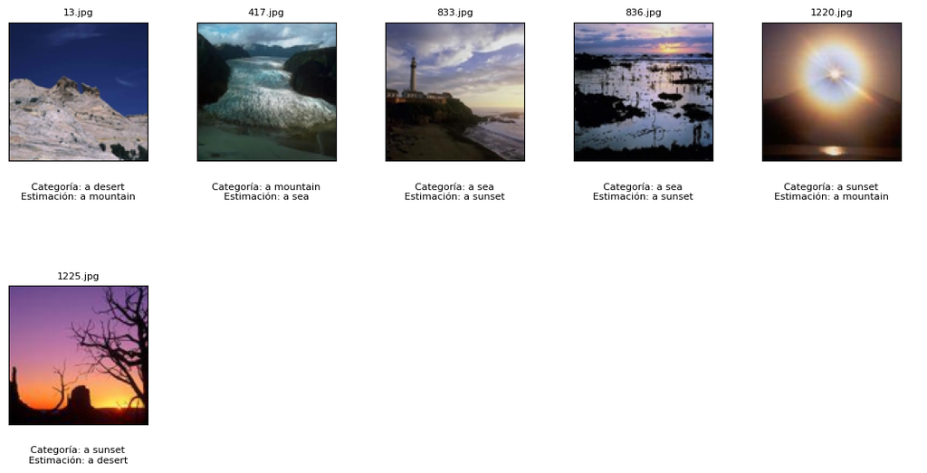

```python
import os, math, textwrap
import matplotlib.pyplot as plt

# Filtra las filas fallidas
fallos_df = df[df["Acierto"] == "No"]
# Nombre real del archivo
path_by_name = {os.path.basename(p): p for p in images_files}
# Prepara (thumb, fname, real, pred)
items = []
for _, row in fallos_df.iterrows():
    fname = row["archivo"]
    p = path_by_name.get(fname)
    if not p:
        continue
    try:
        im = Image.open(p).convert("RGB").resize((100, 100), Image.LANCZOS)
    except Exception:
        continue
    real = str(row["Verdadera"])
    pred = str(row["Predicha"])
    items.append((im, fname, real, pred))
n = len(items)
print(f"Total fallos: {n}")
if n == 0:
    print("No hay misclasificaciones")
else:
    ncols = 5
    nrows = math.ceil(n / ncols)
    fig, axes = plt.subplots(nrows, ncols, figsize=(ncols*2.2, nrows*2.6))
    # Normalizar axes a lista plana
    if nrows == 1 and ncols == 1:
        axes = [[axes]]
    elif nrows == 1:
        axes = [axes]
    elif ncols == 1:
        axes = [[ax] for ax in axes]
    flat_axes = [a for row in axes for a in row]
    for i, ax in enumerate(flat_axes):
        if i < n:
            im, fname, real, pred = items[i]
            ax.imshow(im)
            ax.set_xticks([]); ax.set_yticks([])
            ax.set_title(fname, fontsize=8)
            # Etiqueta debajo
            txt = textwrap.fill(f"Categoría: {real}", width=28) + "\n" + \
                  textwrap.fill(f"Estimación: {pred}", width=28)
            ax.text(0.5, -0.15, txt, transform=ax.transAxes,
                    ha="center", va="top", fontsize=8, clip_on=False)
        else:
            ax.axis("off")
    plt.tight_layout()
    plt.subplots_adjust(hspace=0.9, bottom=0.08)
    plt.show()
```

### Conclusión

**Documento en Colab** [enlace](https://colab.research.google.com/drive/10lPemM2Mx-Tz4GpIgPghBA9ECJiXbIuo?usp=sharing).

### Referencias

1. Ilharco, G., Wortsman, M., Carlini, N., Taori, R., Dave, A., Shankar, V., Namkoong, H., Miller, J., Hajishirzi, H., Farhadi, A., & Schmidt, L. (2021). *OpenCLIP* (Version 0.1) [Computer software]. Zenodo.
2. mlfoundations. (2025). *open_clip: An open source implementation of CLIP* [Computer software].
3. Schuhmann, C., Beaumont, R., Vencu, R., Gordon, C., Wightman, R., Cherti, M., … Jitsev, J. (2022). *LAION-5B: An open large-scale dataset for training next generation image–text models*. *arXiv preprint*, arXiv:2210.08402.